# Data Visualization seaborn

# Boxplot

```
9452.0
```

[output not shown]

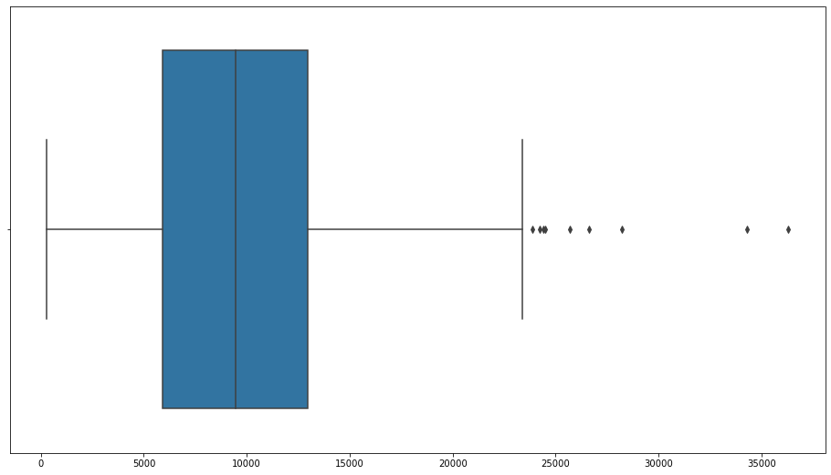

```python
deep = data1['Revenue'].values
x
plt.figure(figsize = (16,9))
sns.boxplot(deep)
print(data1['Revenue'].median())
```

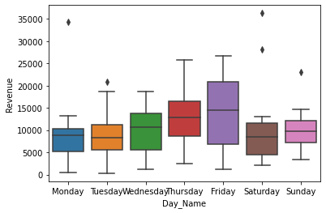

```python
#investiong the distribution of revenue by day_name
sns.boxplot(x = 'Day_Name', y= 'Revenue',data=data1)
```

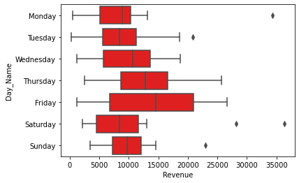

```python
#change the color
sns.boxplot(x = 'Revenue', y= 'Day_Name',data=data1,color='red')
```

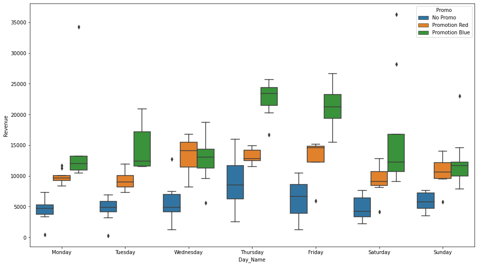

```python
plt.figure(figsize = (16,9))
sns.boxplot(x = 'Day_Name', y= 'Revenue',hue='Promo',data=data1)
```

# Scatter plot Graph

A scatter plot is also called a scatter chart, scattergram, or scatter plot, XY graph. The scatter diagram graphs numerical data pairs, with one variable on each axis, show their relationship. Now the question comes for everyone: when to use a scatter plot?

# Scatter plots are used in either of the following situations.

1. When we have paired numerical data
2. When there are multiple values of the dependent variable for a unique value of an independent variable
3. In determining the relationship between variables in some scenarios, such as identifying potential root causes of problems, checking whether two products that appear to be related both occur with the exact cause and so on.

# Uses and Examples

Scatter plots instantly report a large volume of data. It is beneficial in the following situations –

1. For a large set of data points given
2. Each set comprises a pair of values
3. The given data is in numeric form

# Scatter plot Correlation

We know that the correlation is a statistical measure of the relationship between the two variables’ relative movements. If the variables are correlated, the points will fall along a line or curve. The better the correlation, the closer the points will touch the line. This cause examination tool is considered as one of the seven essential quality tools.

# Types of correlation

The scatter plot explains the correlation between two attributes or variables. It represents how closely the two variables are connected. There can be three such situations to see the relation between the two variables –

1. Positive Correlation
2. Negative Correlation
3. No Correlation
- Positive Correlation -- When the points in the graph are rising, moving from left to right, then the scatter plot shows a positive correlation. It means the values of one variable are increasing with respect to another. Now positive correlation can further be classified into three categories:
- Perfect Positive – Which represents a perfectly straight line-- High Positive – All points are nearby Low Positive – When all the points are scattered
- No Correlation-- When the points are scattered all over the graph and it is difficult to conclude whether the values are increasing or decreasing, then there is no correlation between the variables.

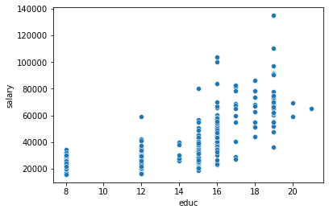

```python
sns.scatterplot(x = 'educ', y= 'salary',data=data)
```

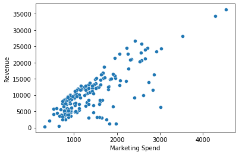

```python
sns.scatterplot(x = 'Marketing Spend', y= 'Revenue',data=data1)
```

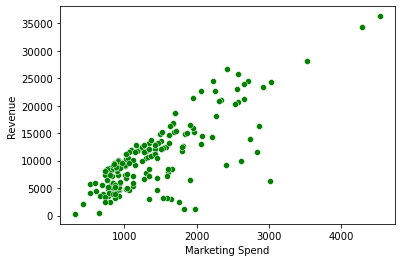

```python
#change the colur of the scatter
sns.scatterplot(x = 'Marketing Spend', y= 'Revenue',data=data1,color='green')
```

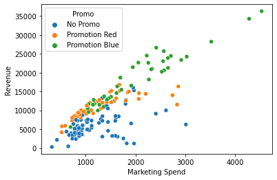

```python
sns.scatterplot(x = 'Marketing Spend', y= 'Revenue',hue='Promo', data=data1)
```

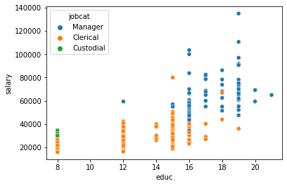

```python
sns.scatterplot(x = 'educ', y= 'salary',data=data,hue='jobcat')
```

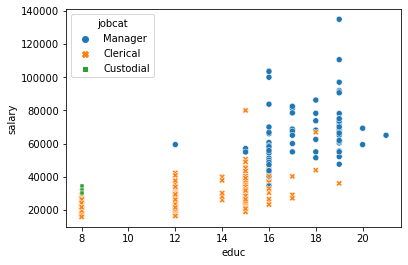

```python
#change the style of the scatter
sns.scatterplot(x = 'educ', y= 'salary',data=data,hue='jobcat',style='jobcat')
```

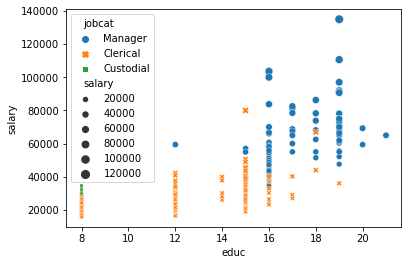

```python
#increage the size
sns.scatterplot(x = 'educ', y= 'salary',data=data,hue='jobcat',style='jobcat',size='salary')
```

# What is a heat map

A heat map (or heatmap) is a graphical representation of data where values are depicted by color. Heat maps make it easy to visualize complex data and understand it at a glance:

# When you should use a heatmap

Heatmaps are used to show relationships between two variables, one plotted on each axis. By observing how cell colors change across each axis, you can observe if there are any patterns in value for one or both variables.

```python
data.corr()
```

|  | id | educ | salary | salbegin | jobtime |
| --- | --- | --- | --- | --- | --- |
| id | 1.000000 | -0.057212 | -0.095544 | 0.007812 | -0.998186 |
| educ | -0.057212 | 1.000000 | 0.660559 | 0.633196 | 0.047379 |
| salary | -0.095544 | 0.660559 | 1.000000 | 0.880117 | 0.084092 |
| salbegin | 0.007812 | 0.633196 | 0.880117 | 1.000000 | -0.019753 |
| jobtime | -0.998186 | 0.047379 | 0.084092 | -0.019753 | 1.000000 |

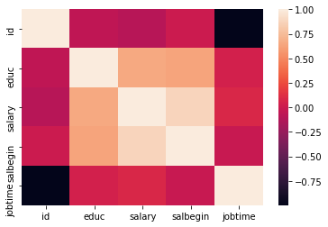

```python
sns.heatmap(data.corr())
```

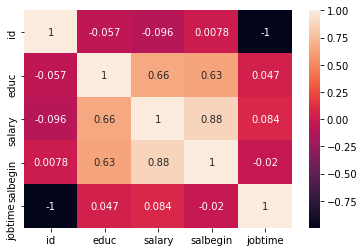

```python
sns.heatmap(data.corr(),annot = True)
```

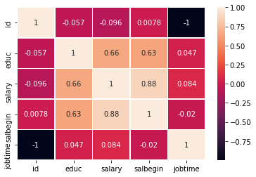

```python
sns.heatmap(data.corr(),annot = True,linewidth=0.5)
```

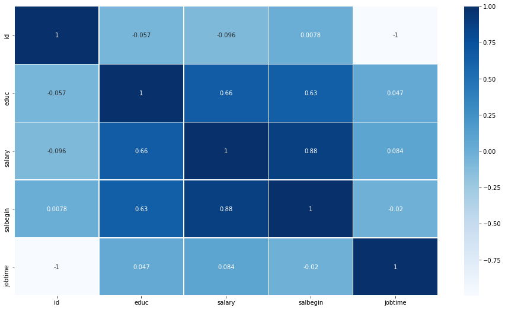

```python
plt.figure(figsize=(16,9))
sns.heatmap(data.corr(),annot = True,linewidth=0.5,cmap='Blues')
```

# pairplot

- A pairs plot allows us to see both distribution of single variables and relationships between two variables. Pair plots are a great method to identify trends for follow-up analysis and, fortunately, are easily implemented in Python!
- a par plot is also knonwn as scatterplot in which one variable in the same data row is matched with another variable valuelike this paris plots are just elaborations on this showing all varibles paired with all the other variables

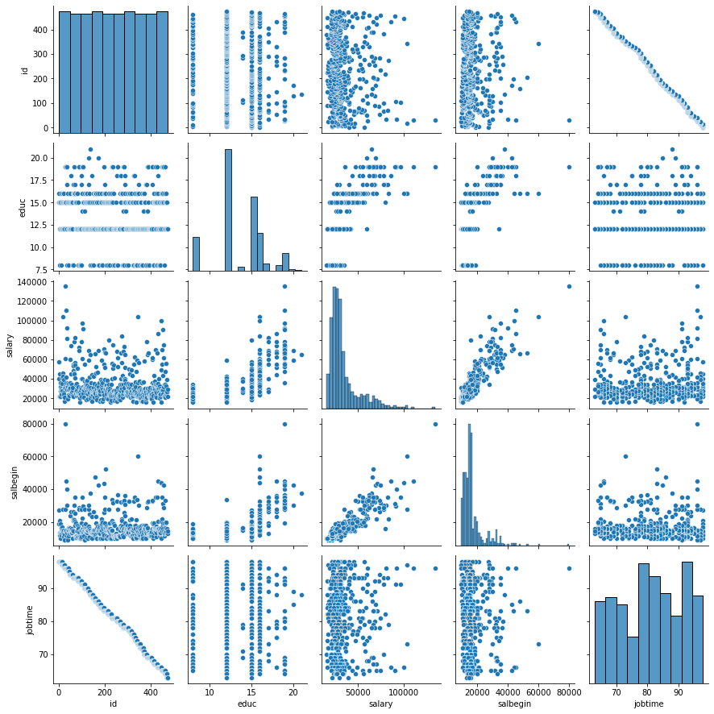

```python
sns.pairplot(data)
```

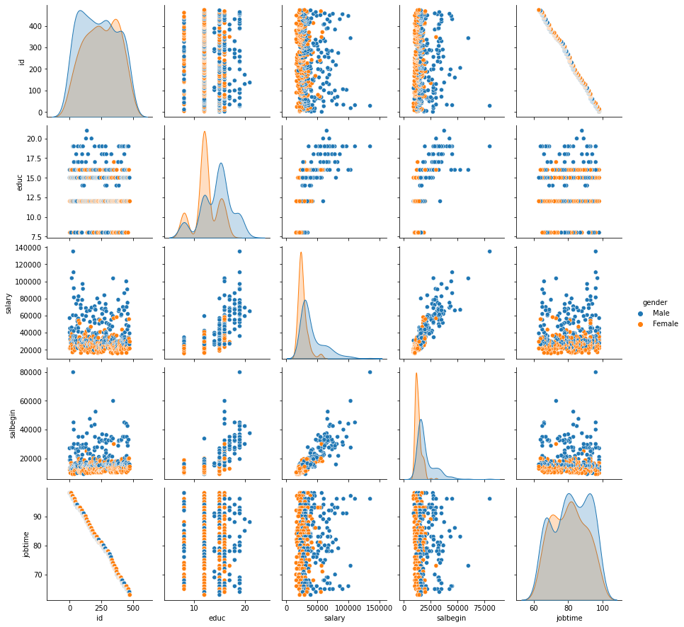

```python
sns.pairplot(data,hue='gender')
```

# joint plot

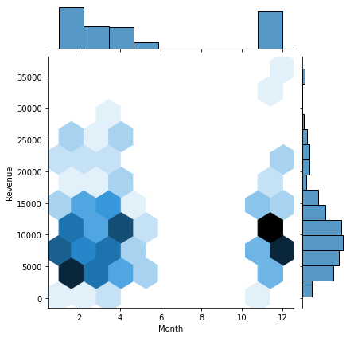

```python
sns.jointplot(x ='Month' ,y = 'Revenue',data =data1,kind ='hex')
```

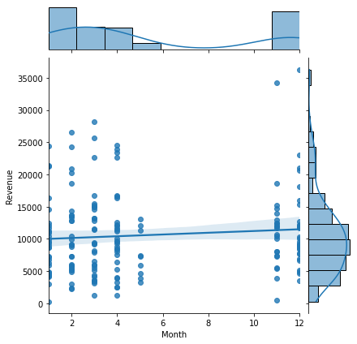

```python
sns.jointplot(x ='Month' ,y = 'Revenue',data =data1,kind ='reg')
```

# subplot

How does subplot work in Python? subplots creates a figure and a grid of subplots with a single call, while providing reasonable control over how the individual plots are created. For more advanced use cases you can use GridSpec for a more general subplot layout or Figure. add_subplot for adding subplots at arbitrary locations within the figure.